# MATH9102-W11-LogReg-Exercise

Author

Deirdre Lawless

# Task 1: Build a Simple Logistic Regression: Can trouble sleeping be predicted by whether someone is a smoker?

## Step 1: Build the model

```r
#Make sure categorical data is used as factors

logmodel1 <- glm(trubslep_num~ smoke, data =sleepdf, na.action = na.exclude, family = binomial(link=logit))
```

## Step 2: Generate Summary Statistics to Assess Model Fit

### Step 2a: Summary of Model

```r
#Full summary of the model
summary(logmodel1)
```

```
Call:
glm(formula = trubslep_num ~ smoke, family = binomial(link = logit),
    data = sleepdf, na.action = na.exclude)

Coefficients:
            Estimate Std. Error z value Pr(>|z|)
(Intercept)  -0.4944     0.1368  -3.614 0.000302 ***
smokeyes      0.6767     0.3754   1.803 0.071452 .
---
Signif. codes:  0 '***' 0.001 '**' 0.01 '*' 0.05 '.' 0.1 ' ' 1

(Dispersion parameter for binomial family taken to be 1)

    Null deviance: 349.97  on 259  degrees of freedom
Residual deviance: 346.70  on 258  degrees of freedom
AIC: 350.7

Number of Fisher Scoring iterations: 4
```

### Step 2b: Omnibus Test of Model

```r
#Chi-square plus significance
lmtest::lrtest(logmodel1)
```

```
Likelihood ratio test

Model 1: trubslep_num ~ smoke
Model 2: trubslep_num ~ 1
  #Df  LogLik Df  Chisq Pr(>Chisq)
1   2 -173.35
2   1 -174.98 -1 3.2622     0.0709 .
---
Signif. codes:  0 '***' 0.001 '**' 0.01 '*' 0.05 '.' 0.1 ' ' 1
```

### Step 2c: Pseudo R2 Statistics

```r
#Pseudo Squared
DescTools::PseudoR2(logmodel1, which="CoxSnell")
```

```
  CoxSnell
0.01246844
```

```r
DescTools::PseudoR2(logmodel1, which="Nagelkerke")
```

```
Nagelkerke
0.01685546
```

```r
performance::r2(logmodel1) # Will return Tujur's Pseudo R2
```

```
# R2 for Logistic Regression
  Tjur's R2: 0.013
```

## (Optional): Use Stargazer to Report

```r
#Summary of the model with co-efficients
stargazer(logmodel1, type="text", star.cutoffs = c(0.05, 0.01, 0.001))
```

```
===============================================
                       Dependent variable:
                  -----------------------------
                          trubslep_num
-----------------------------------------------
smokeyes                      0.677
                             (0.375)

Constant                    -0.494***
                             (0.137)

-----------------------------------------------
Observations                   260
Log Likelihood              -173.352
Akaike Inf. Crit.            350.704
===============================================
Note:             *p<0.05; **p<0.01; ***p<0.001
```

### Your task: Interpret the fit and usefulness

## Step 3: Calculate Odds Ratios and Probability of Co-efficients

```r
# Odds ratios only
parameters::parameters(logmodel1, exponentiate = TRUE) %>%
  as.data.frame() %>%
  dplyr::select(Parameter, OddsRatio = Coefficient)
```

```
    Parameter OddsRatio
1 (Intercept) 0.6099291
2    smokeyes 1.9674419
```

```r
# Predicted probabilities by smoke
emmeans::emmeans(logmodel1, ~ smoke, type = "response")
```

```
 smoke  prob     SE  df asymp.LCL asymp.UCL
 no    0.379 0.0322 Inf     0.318     0.444
 yes   0.545 0.0867 Inf     0.377     0.704

Confidence level used: 0.95
Intervals are back-transformed from the logit scale
```

### Your task: Interpret the odds ratios and predicted probabilities

## Step 4: Assess Classification Performance

## Step 4a: Generate a ROC curve and Calculate Sensitivity, Specificity and AUC

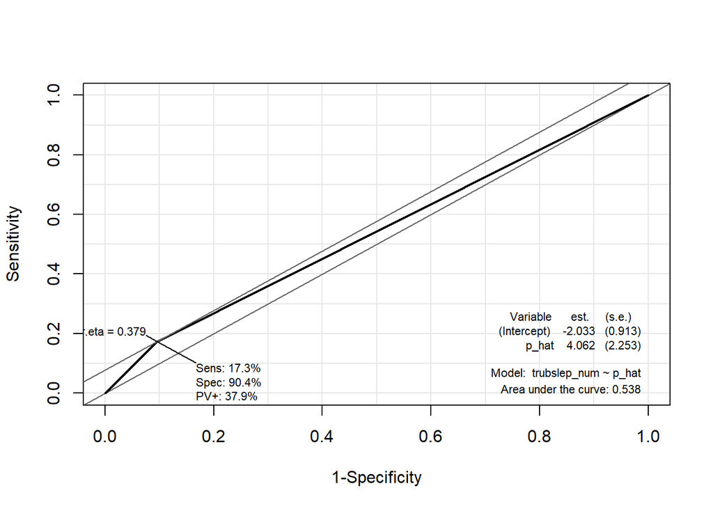

Figure 1: ROC curve for Model1

```r
# Generate predicted probabilities for Model 1
p_hat <- stats::predict(logmodel1, type = "response")

# Build results1 data frame for Epi::ROC
results1 <- sleepdf %>%
  dplyr::mutate(
    trubslep_num = trubslep_num,   # already created earlier
    p_hat = p_hat                # predicted probabilities
  ) %>%
  dplyr::select(trubslep_num, p_hat) %>%     # only keep needed columns
  dplyr::filter(!is.na(trubslep_num))        # remove NA cases

# Generate the curve
roc1 <-Epi::ROC(
  form = trubslep_num ~ p_hat,
  data = results1,
  plot = "ROC"
)
```

### Your Task: Interpret the ROC curve, sensitivity, specificity, AUC

### Step 4b: Generate a Confusion Matrix

```r
results1 <- sleepdf %>%
  dplyr::mutate(
    actual = factor(trubslep_num, levels = c(0,1)),
    pred_class = factor(
      ifelse(stats::predict(logmodel1, type = "response") > 0.5, 1, 0),
      levels = c(0,1)
    )
  )


cm <- yardstick::conf_mat(
  data = results1,
  truth = actual,
  estimate = pred_class
)

cm
```

```
          Truth
Prediction   0   1
         0 141  86
         1  15  18
```

### Your task: Interpret the Confusion Matrix

## Step 5: Check Model Meets Assumptions of Logistic Regression

### Step 5a: Linearity of Independent Variables and Log Odds

```r
#Check the assumption of linearity of independent variables and log odds using a Hosmer-Lemeshow test, if this is not statistically significant we are OK
generalhoslem::logitgof(sleepdf$trubslep_num, fitted(logmodel1))
```

```
    Hosmer and Lemeshow test (binary model)

data:  sleepdf$trubslep_num, fitted(logmodel1)
X-squared = 4.2137e-28, df = -1, p-value = NA
```

### Step 5b: Collinearity

```r
#We would check for collinearity here but as we only have one predictor it doesn't make sense - check model 2 to see how to do this
```

### Step 5c: Outliers and Influential Cases

- **Cook’s Distance**: Measures how much each individual observation influences the overall model; large values indicate cases that may disproportionately affect the results.
- **Leverage (Hat values)**: Identifies observations with unusual predictor values; high-leverage cases have the potential to pull the model toward themselves.
- **Standardised (Pearson) residuals**: Show how poorly each observation is predicted by the model; large residuals (e.g., > |2|) indicate unusual or poorly fitted cases.
- **Deviance residuals**: Reflect how much each observation contributes to the model’s deviance; large values highlight observations the model struggles to accurately classify.
- **DFBetas**: Measure how much each observation influences individual regression coefficients; large DFBetas indicate that removing the case would substantially change a coefficient estimate.

```r
# 1. Cook's Distance
cook <- cooks.distance(logmodel1)

# View largest Cook's D values
head(sort(cook, decreasing = TRUE))
```

```
        59         63         67         75         81         91
0.01933594 0.01933594 0.01933594 0.01933594 0.01933594 0.01933594
```

```r
# Flag influential cases (common threshold: D > 1)
which(cook > 1)
```

```
named integer(0)
```

```r
# 2. Leverage (Hat values)
lev <- hatvalues(logmodel1)

# View highest leverage cases
head(sort(lev, decreasing = TRUE))
```

```
         4         10         14         22         29         44
0.03030303 0.03030303 0.03030303 0.03030303 0.03030303 0.03030303
```

```r
# Flag high leverage cases
# Rule of thumb: h_i > 2*(k+1)/n
k <- length(coef(logmodel1)) - 1  # number of predictors
n <- nobs(logmodel1)
lev_threshold <- 2*(k+1)/n

#Count how many exceed threshold
sum(lev > lev_threshold)
```

```
[1] 33
```

```r
#Count how many > .2
sum(lev > 0.2)
```

```
[1] 0
```

```r
which(lev > lev_threshold)
```

```
  4  10  14  22  29  44  49  59  63  67  75  81  91  98 100 108 131 133 157 170
  3   9  13  21  28  43  48  58  62  66  73  78  87  94  96 104 126 128 152 164
173 176 178 181 183 184 186 194 197 204 228 242 246
167 169 171 174 176 177 179 187 189 196 220 232 236
```

```r
# 3. DFBetas (influence on individual coefficients)
dfb <- dfbeta(logmodel1)

# Identify cases with large DFBetas (|DFB| > 1 is concerning)
which(abs(dfb) > 1, arr.ind = TRUE)
```

```
     row col
```

```r
# 4. Standardised (Pearson) residuals
pearson_resid <- rstandard(logmodel1, type = "pearson")

# Flag large residuals (|residual| > 2 or > 3)
which(abs(pearson_resid) > 2)
```

```
named integer(0)
```

```r
# Optional: look at the largest ones
head(sort(abs(pearson_resid), decreasing = TRUE))
```

```
       2        3        5        6        7        8
1.283273 1.283273 1.283273 1.283273 1.283273 1.283273
```

```r
# 5. Deviance residuals
dev_resid <- residuals(logmodel1, type = "deviance")

# Flag extreme deviance residuals
which(abs(dev_resid) > 2)
```

```
named integer(0)
```

### Your Task: Interpret the assumption checks

## Step 6: Report

### Your task: Write the report

## Conclusion Model 1

### Your Task: What can you conclude

# Task 2: Build a Simple Logistic Regression with Multiple Predictors: Can trouble sleeping be predicted by whether someone is a smoker and their caffeine intake?

## Step 1: Build the model

```r
#Make sure categorical data is used as factors

logmodel2 <- glm(trubslep_num~ smoke+caffeine, data = sleepdf, na.action = na.exclude, family = binomial(link=logit))
```

## Step 2: Generate Summary Statistics to Assess Model Fit

### Step 2a: Summary of Model

```r
#Full summary of the model
summary(logmodel2)
```

```
Call:
glm(formula = trubslep_num ~ smoke + caffeine, family = binomial(link = logit),
    data = sleepdf, na.action = na.exclude)

Coefficients:
            Estimate Std. Error z value Pr(>|z|)
(Intercept) -0.33571    0.23513  -1.428   0.1534
smokeyes     0.69158    0.37642   1.837   0.0662 .
caffeine    -0.05521    0.06711  -0.823   0.4107
---
Signif. codes:  0 '***' 0.001 '**' 0.01 '*' 0.05 '.' 0.1 ' ' 1

(Dispersion parameter for binomial family taken to be 1)

    Null deviance: 349.97  on 259  degrees of freedom
Residual deviance: 346.02  on 257  degrees of freedom
AIC: 352.02

Number of Fisher Scoring iterations: 4
```

### Step 2b: Omnibus Test of Model

```r
#Chi-square plus significance
lmtest::lrtest(logmodel2)
```

```
Likelihood ratio test

Model 1: trubslep_num ~ smoke + caffeine
Model 2: trubslep_num ~ 1
  #Df  LogLik Df  Chisq Pr(>Chisq)
1   3 -173.01
2   1 -174.98 -2 3.9456     0.1391
```

### Step 2c: Pseudo R2 Statistics

```r
#Pseudo Squared
DescTools::PseudoR2(logmodel2, which="CoxSnell")
```

```
  CoxSnell
0.01506083
```

```r
DescTools::PseudoR2(logmodel2, which="Nagelkerke")
```

```
Nagelkerke
0.02035999
```

```r
performance::r2(logmodel2) # Will return Tujur's Pseudo R2
```

```
# R2 for Logistic Regression
  Tjur's R2: 0.015
```

## (Optional): Use Stargazer to Report

```r
#Summary of the model with co-efficients
stargazer(logmodel2, type="text", star.cutoffs = c(0.05, 0.01, 0.001))
```

```
===============================================
                       Dependent variable:
                  -----------------------------
                          trubslep_num
-----------------------------------------------
smokeyes                      0.692
                             (0.376)

caffeine                     -0.055
                             (0.067)

Constant                     -0.336
                             (0.235)

-----------------------------------------------
Observations                   260
Log Likelihood              -173.010
Akaike Inf. Crit.            352.020
===============================================
Note:             *p<0.05; **p<0.01; ***p<0.001
```

### Your task: Interpret the fit and usefulness

## Step 3: Calculate Odds Ratios and Probability of Co-efficients

```r
# Odds ratios only
parameters::parameters(logmodel2, exponentiate = TRUE) %>%
  as.data.frame() %>%
  dplyr::select(Parameter, OddsRatio = Coefficient)
```

```
    Parameter OddsRatio
1 (Intercept) 0.7148312
2    smokeyes 1.9968588
3    caffeine 0.9462878
```

```r
# Predicted probabilities by smoke
emmeans::emmeans(logmodel2, ~ smoke, type = "response")
```

```
 smoke  prob     SE  df asymp.LCL asymp.UCL
 no    0.378 0.0322 Inf     0.317     0.443
 yes   0.548 0.0868 Inf     0.379     0.707

Confidence level used: 0.95
Intervals are back-transformed from the logit scale
```

```r
# Predicted probabilities by caffeine
emmeans::emmeans(logmodel2, ~ caffeine, type = "response")
```

```
 caffeine  prob     SE  df asymp.LCL asymp.UCL
     2.93 0.462 0.0467 Inf     0.373     0.554

Results are averaged over the levels of: smoke
Confidence level used: 0.95
Intervals are back-transformed from the logit scale
```

```r
# Full grid of predictions for ALL combinations

pred_grid <- emmeans::emmeans(
  logmodel2,
  ~ smoke * caffeine,   # <-- interaction in predictions, even if not in model
  type = "response"
)
```

### Your task: Interpret the odds ratios and predicted probabilities

## Step 4: Assess Classification Performance

### Step 4a: Generate a ROC curve and Calculate Sensitivity, Specificity and AUC

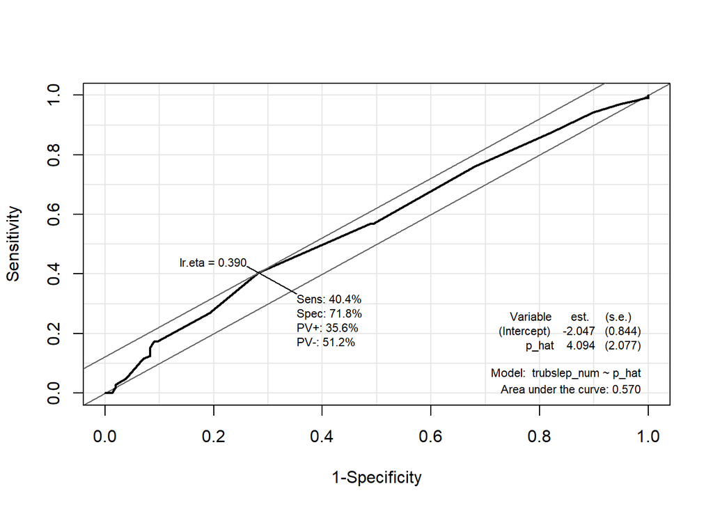

Figure 2: ROC curve for Model 2

```r
# Generate predicted probabilities for Model 2
p_hat <- stats::predict(logmodel2, type = "response")

# Build results2 data frame for Epi::ROC
results2 <- sleepdf %>%
  dplyr::mutate(
    trubslep_num = trubslep_num,   # already created earlier
    p_hat = p_hat                # predicted probabilities
  ) %>%
  dplyr::select(trubslep_num, p_hat) %>%     # only keep needed columns
  dplyr::filter(!is.na(trubslep_num))        # remove NA cases

# Generate the curve
roc1 <-Epi::ROC(
  form = trubslep_num ~ p_hat,
  data = results2,
  plot = "ROC"
)
```

### Your Task: Interpret the ROC curve, sensitivity, specificity, AUC

### Step 4b: Generate a Confusion Matrix

```r
results2 <- sleepdf %>%
  dplyr::mutate(
    actual = factor(trubslep_num, levels = c(0,1)),
    pred_class = factor(
      ifelse(stats::predict(logmodel2, type = "response") > 0.5, 1, 0),
      levels = c(0,1)
    )
  )


cm <- yardstick::conf_mat(
  data = results2,
  truth = actual,
  estimate = pred_class
)

cm
```

```
          Truth
Prediction   0   1
         0 142  86
         1  14  18
```

### Your task: Interpret the Confusion Matrix

## Step 5: Check Model Meets Assumptions of Logistic Regression

### Step 5a: Linearity of Independent Variables and Log Odds

```r
#Check the assumption of linearity of independent variables and log odds using a Hosmer-Lemeshow test, if this is not statistically significant we are OK
generalhoslem::logitgof(sleepdf$trubslep_num, fitted(logmodel2))
```

```
    Hosmer and Lemeshow test (binary model)

data:  sleepdf$trubslep_num, fitted(logmodel2)
X-squared = 3.4631, df = 6, p-value = 0.7489
```

### Step 5b: Collinearity

```r
#Check collinearity

vifmodel<-car::vif(logmodel2)#You can ignore the warning messages, GVIF^(1/(2*Df)) is the value of interest
vifmodel
```

```
   smoke caffeine
1.002911 1.002911
```

```r
#Tolerance
1/vifmodel
```

```
    smoke  caffeine
0.9970971 0.9970971
```

### Step 5c: Outliers and Influential Cases

- **Cook’s Distance**: Measures how much each individual observation influences the overall model; large values indicate cases that may disproportionately affect the results.
- **Leverage (Hat values)**: Identifies observations with unusual predictor values; high-leverage cases have the potential to pull the model toward themselves.
- **Standardised (Pearson) residuals**: Show how poorly each observation is predicted by the model; large residuals (e.g., > |2|) indicate unusual or poorly fitted cases.
- **Deviance residuals**: Reflect how much each observation contributes to the model’s deviance; large values highlight observations the model struggles to accurately classify.
- **DFBetas**: Measure how much each observation influences individual regression coefficients; large DFBetas indicate that removing the case would substantially change a coefficient estimate.

```r
# 1. Cook's Distance
cook <- cooks.distance(logmodel2)

# View largest Cook's D values
head(sort(cook, decreasing = TRUE))
```

```
         2         41         63        157         91        197
0.04632916 0.02299527 0.02093226 0.02093226 0.01961333 0.01693995
```

```r
# Flag influential cases (common threshold: D > 1)
which(cook > 1)
```

```
named integer(0)
```

```r
# 2. Leverage (Hat values)
lev <- hatvalues(logmodel2)

# View highest leverage cases
head(sort(lev, decreasing = TRUE))
```

```
        91          2         63        157        116         22
0.05700988 0.05146568 0.04050184 0.04050184 0.03997373 0.03976901
```

```r
# Flag high leverage cases
# Rule of thumb: h_i > 2*(k+1)/n
k <- length(coef(logmodel2)) - 1  # number of predictors
n <- nobs(logmodel2)
lev_threshold <- 2*(k+1)/n

#Count how many exceed threshold
sum(lev > lev_threshold)
```

```
[1] 39
```

```r
#Count how many > .2
sum(lev > 0.2)
```

```
[1] 0
```

```r
which(lev > lev_threshold)
```

```
  2   4  10  14  22  29  41  44  49  59  63  67  75  81  91  98 100 108 116 131
  1   3   9  13  21  28  40  43  48  58  62  66  73  78  87  94  96 104 112 126
133 157 170 173 176 178 181 183 184 186 194 197 204 222 228 230 242 246 263
128 152 164 167 169 171 174 176 177 179 187 189 196 214 220 222 232 236 252
```

```r
# 3. DFBetas (influence on individual coefficients)
dfb <- dfbeta(logmodel2)

print(paste("Threshold is: ", lev_threshold))
```

```
[1] "Threshold is:  0.0230769230769231"
```

```r
# Identify cases with large DFBetas (|DFB| > 1 is concerning)
which(abs(dfb) > 1, arr.ind = TRUE)
```

```
     row col
```

```r
# 4. Standardised (Pearson) residuals
pearson_resid <- rstandard(logmodel2, type = "pearson")

# Flag large residuals (|residual| > 2 or > 3)
which(abs(pearson_resid) > 2)
```

```
named integer(0)
```

```r
# Optional: look at the largest ones
head(sort(abs(pearson_resid), decreasing = TRUE))
```

```
       2       41       20        5      210      245
1.600500 1.497560 1.450353 1.405862 1.405862 1.405862
```

```r
# 5. Deviance residuals
dev_resid <- residuals(logmodel2, type = "deviance")

# Flag extreme deviance residuals
which(abs(dev_resid) > 2)
```

```
named integer(0)
```

### Your Task: Interpret the assumption checks

## Step 6: Report

### Your task: Write the report

### Your task: Write a Conclusion about the model

## Your task: Write a comparison between model 1 and 2